# Practical Machine Learning: Course Project

y chahid

10 April 2016

## Executive Summary

In the following report we will see that using machine learning can help in investigating how well an activity is performed.  
Following is a demonstration of a model that classifies with very high accuracy the ‘how well’ a weight lifting exercise is executed.

## Background

Using devices such as Jawbone Up, Nike FuelBand, and Fitbit it is now possible to collect a large amount of data about personal activity relatively inexpensively. These type of devices are part of the quantified self movement - a group of enthusiasts who take measurements about themselves regularly to improve their health, to find patterns in their behavior, or because they are tech geeks. One thing that people regularly do is quantify how much of a particular activity they do, but they rarely quantify how well they do it.

In this project, our goal will be to predict how well weight lifting exercise is executed, by using data from accelerometers on the belt, forearm, arm, and dumbell of 6 participants. They were asked to perform barbell lifts correctly and incorrectly in 5 different ways.

## Load Data and Libraries

```r
suppressMessages(library(caret))
set.seed(33333)
training<-read.csv("pml-training.csv", na.strings=c("","#DIV/0!","NA"))
testing<-read.csv("pml-testing.csv", na.strings=c("","#DIV/0!","NA"))
```

## Data exploration and Cleaning

The dataset comes with a large number of variables, many of them contains a big percentage of NA values and there also other variables that are irrelevant (timestamps, line number, problem_id ..), that we will delete:

```r
dim(training)
```

```
## [1] 19622   160
```

```r
dim(testing)
```

```
## [1]  20 160
```

```r
# delete first seven variables as being irrelevant,
training<-training[,-c(1:7)]
testing<-testing[,-c(1:7)]
#count percentage of Na values for each column,
rateNATr <- sapply(training, function(x) {sum(is.na(x)==TRUE)/length(x)})
rateNATs <- sapply(testing, function(x) {sum(is.na(x)==TRUE)/length(x)})
#extract variables with more than 80% non NA values= variables to keep
keepTr <- names(which(rateNATr < 0.8))
keepTs <- names(which(rateNATs < 0.8))
#apply preprocess non NA rule on both training and test sets
training <- training[, keepTr]
testing <- testing[, keepTs]
```

## Split training and test sets

```r
inTrain <- createDataPartition (training$classe, p=0.7, list=FALSE)
training.train <- training [inTrain ,]
training.test <- training [-inTrain,]
```

## Fitting the model

This is a classification problem, and random forests are highly recommended for this kind of modelling, we will fit a random forest model with the default k fold cross validation number, and 100 trees, we can readjust these values after evaluation.

```r
ctrl <- trainControl(method = "cv", number=10)
rfmodel <- train(classe ~ ., data = training.train, method = "rf", trControl = ctrl, allowParallel=TRUE, ntree=100)
print(rfmodel)
```

```
## Random Forest
##
## 13737 samples
##    52 predictor
##     5 classes: 'A', 'B', 'C', 'D', 'E'
##
## No pre-processing
## Resampling: Cross-Validated (10 fold)
## Summary of sample sizes: 12363, 12365, 12365, 12362, 12366, 12362, ...
## Resampling results across tuning parameters:
##
##   mtry  Accuracy   Kappa      Accuracy SD  Kappa SD
##    2    0.9911198  0.9887657  0.002513269  0.003180418
##   27    0.9917737  0.9895939  0.002328510  0.002945825
##   52    0.9834746  0.9790944  0.002895581  0.003663212
##
## Accuracy was used to select the optimal model using  the largest value.
## The final value used for the model was mtry = 27.
```

## Model evaluation

Let’s create a confusion matrix to check the accuracy of the model

```r
predict.test <- predict(rfmodel, newdata = training.test)
confusionMatrix(data = predict.test, training.test$classe)
```

```
## Confusion Matrix and Statistics
##
##           Reference
## Prediction    A    B    C    D    E
##          A 1672    6    0    1    0
##          B    2 1128    4    0    0
##          C    0    5 1019   11    0
##          D    0    0    3  950    3
##          E    0    0    0    2 1079
##
## Overall Statistics
##
##                Accuracy : 0.9937
##                  95% CI : (0.9913, 0.9956)
##     No Information Rate : 0.2845
##     P-Value [Acc > NIR] : < 2.2e-16
##
##                   Kappa : 0.992
##  Mcnemar's Test P-Value : NA
##
## Statistics by Class:
##
##                      Class: A Class: B Class: C Class: D Class: E
## Sensitivity            0.9988   0.9903   0.9932   0.9855   0.9972
## Specificity            0.9983   0.9987   0.9967   0.9988   0.9996
## Pos Pred Value         0.9958   0.9947   0.9845   0.9937   0.9981
## Neg Pred Value         0.9995   0.9977   0.9986   0.9972   0.9994
## Prevalence             0.2845   0.1935   0.1743   0.1638   0.1839
## Detection Rate         0.2841   0.1917   0.1732   0.1614   0.1833
## Detection Prevalence   0.2853   0.1927   0.1759   0.1624   0.1837
## Balanced Accuracy      0.9986   0.9945   0.9949   0.9921   0.9984
```

On our first try with random forest, we can see that we obtain a highly accurate model with a very small out of sample error.

Just for information we visualize a list of the order of importance of contributing predictors:

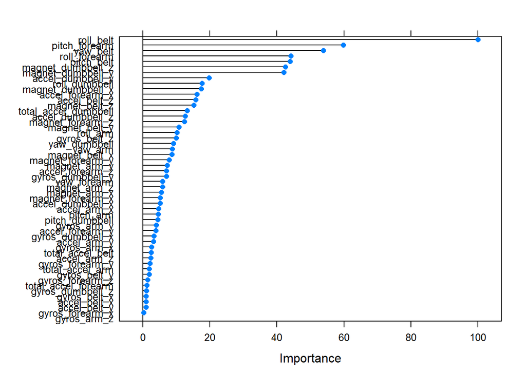

```r
print(plot(varImp(rfmodel)))
```

## Prediction on new sample

we will use the fitted model to predict on the new sample

```r
predict.new <- predict(rfmodel, testing)
predict.new
```

```
##  [1] B A B A A E D B A A B C B A E E A B B B
## Levels: A B C D E
```

## References

http://groupware.les.inf.puc-rio.br/har